# Topic 3 — Simple Linear Regression

Course Materials

2026-07-12

# 1 Theory

## 1.1 The model

$$y_i = \beta_0 + \beta_1 x_i + \varepsilon_i, \qquad \varepsilon_i \sim
N(0, \sigma^2) \text{ i.i.d.}$$

Estimation is by ordinary least squares (OLS), minimizing $\sum \hat\varepsilon_i^2$:

$$\hat\beta_1 = \frac{\sum (x_i - \bar x)(y_i - \bar y)}{\sum (x_i - \bar
x)^2} = \frac{S_{xy}}{S_{xx}}, \qquad \hat\beta_0 = \bar y - \hat\beta_1
\bar x$$

## 1.2 Modelling assumptions (the “LINE” conditions)

1. **L**inearity: $E[y|x]$ is linear in $x$.
2. **I**ndependence: errors are independent of each other (no autocorrelation).
3. **N**ormality: errors are normally distributed (needed for exact $t$/$F$ inference in small samples; less critical as $n$ grows, by CLT).
4. **E**qual variance (homoscedasticity): $Var(\varepsilon_i) = \sigma^2$ constant across $x$.

Diagnostics: residuals vs. fitted (linearity, homoscedasticity), Q-Q plot of residuals (normality), Durbin-Watson (independence, mainly for time series).

## 1.3 Goodness of fit: $R^2$

$$R^2 = \frac{SSR}{SST} = 1 - \frac{SSE}{SST}, \qquad SST = SSR + SSE$$

where $SST = \sum(y_i-\bar y)^2$ (total variation), $SSR = \sum(\hat y_i - \bar y)^2$ (explained), $SSE = \sum(y_i - \hat y_i)^2$ (residual/unexplained). $R^2$ is the proportion of variance in $y$ explained by $x$; in simple regression, $R^2 = r_{xy}^2$ (squared correlation).

## 1.4 t-test on the slope

$$H_0: \beta_1 = 0 \qquad H_1: \beta_1 \neq 0$$

$$t = \frac{\hat\beta_1 - 0}{SE(\hat\beta_1)}, \qquad SE(\hat\beta_1) =
\frac{s}{\sqrt{S_{xx}}}, \qquad df = n-2$$

where $s = \sqrt{SSE/(n-2)}$ is the residual standard error. Rejecting $H_0$ means $x$ has a statistically significant linear association with $y$.

## 1.5 F-test / ANOVA (overall significance)

In simple regression, the F-test is mathematically equivalent to the t-test on the slope ($F = t^2$), because there’s only one predictor. The ANOVA decomposition:

| Source | SS | df | MS | F |
| --- | --- | --- | --- | --- |
| Regression | $SSR$ | 1 | $MSR = SSR/1$ | $F = MSR/MSE$ |
| Residual | $SSE$ | $n-2$ | $MSE = SSE/(n-2)$ |  |
| Total | $SST$ | $n-1$ |  |  |

$$H_0: \beta_1 = 0 \text{ (model has no explanatory power)} \qquad H_1:
\beta_1 \neq 0$$

Reject in the upper tail of $F_{1, n-2}$ (like chi-squared, F-statistics are ratios of sums of squares, so only large values count against $H_0$).

## 1.6 Coefficient and business interpretation

- $\hat\beta_1$: expected change in $y$ for a one-unit increase in $x$, holding nothing else constant (there’s nothing else in simple regression).
- $\hat\beta_0$: expected value of $y$ when $x=0$ — often not practically meaningful if $x=0$ is outside the observed data range (extrapolation risk).
- Always pair statistical significance ($p$-value) with **practical/business significance** (is the effect size large enough to matter for a decision?).

# 2 Exercises

**Exercise 1 (by hand + R).** A marketing team wants to know if monthly ad spend (R$ mil) predicts monthly sales (R$ mil) for 10 store locations:

| Ad spend (x) | 5 | 8 | 10 | 12 | 6 | 14 | 9 | 11 | 7 | 13 |
| --- | --- | --- | --- | --- | --- | --- | --- | --- | --- | --- |
| Sales (y) | 55 | 72 | 84 | 95 | 60 | 108 | 78 | 90 | 65 | 100 |

Estimate the regression line by hand (compute $S_{xy}$, $S_{xx}$, $\hat\beta_0$, $\hat\beta_1$), then verify with R, run the full diagnostics, and interpret in business terms.

# 3 Solution

## 3.1 Step 1 — Manual calculation

$$\bar x = 9.5, \qquad \bar y = 80.7$$

$$S_{xx} = \sum(x_i-\bar x)^2, \qquad S_{xy} = \sum(x_i - \bar x)(y_i -
\bar y)$$

```r
x <- c(5, 8, 10, 12, 6, 14, 9, 11, 7, 13)
y <- c(55, 72, 84, 95, 60, 108, 78, 90, 65, 100)

xbar <- mean(x); ybar <- mean(y)
Sxx <- sum((x - xbar)^2)
Sxy <- sum((x - xbar) * (y - ybar))

beta1_hat <- Sxy / Sxx
beta0_hat <- ybar - beta1_hat * xbar

cat("xbar:", xbar, " ybar:", ybar, "\n")
```

```
## xbar: 9.5  ybar: 80.7
```

```r
cat("Sxx:", Sxx, " Sxy:", Sxy, "\n")
```

```
## Sxx: 82.5  Sxy: 483.5
```

```r
cat("beta1_hat (slope):", round(beta1_hat, 4), "\n")
```

```
## beta1_hat (slope): 5.8606
```

```r
cat("beta0_hat (intercept):", round(beta0_hat, 4), "\n")
```

```
## beta0_hat (intercept): 25.0242
```

## 3.2 Step 2 — Fit in R and full model summary

```r
model <- lm(y ~ x)
summary(model)
```

```
##
## Call:
## lm(formula = y ~ x)
##
## Residuals:
##     Min      1Q  Median      3Q     Max
## -1.2121 -0.3106  0.1606  0.4742  0.9273
##
## Coefficients:
##             Estimate Std. Error t value Pr(>|t|)
## (Intercept) 25.02424    0.81923   30.55 1.43e-09 ***
## x            5.86061    0.08254   71.00 1.72e-12 ***
## ---
## Signif. codes:  0 '***' 0.001 '**' 0.01 '*' 0.05 '.' 0.1 ' ' 1
##
## Residual standard error: 0.7497 on 8 degrees of freedom
## Multiple R-squared:  0.9984, Adjusted R-squared:  0.9982
## F-statistic:  5041 on 1 and 8 DF,  p-value: 1.725e-12
```

**Reading the output:**

- **Coefficients table**: matches our by-hand slope/intercept. The `t value` and `Pr(>|t|)` columns for `x` give the t-test on $\beta_1$: $H_0: \beta_1=0$ vs $H_1: \beta_1 \neq 0$. A tiny p-value here means ad spend has a statistically significant linear relationship with sales.
- **R-squared**: proportion of variance in sales explained by ad spend.
- **F-statistic** (bottom line): tests overall model significance; with one predictor, notice $F = t^2$ for the slope’s t-value — same conclusion, same p-value, by construction.

```r
t_val <- summary(model)$coefficients["x", "t value"]
f_val <- summary(model)$fstatistic["value"]
cat("t^2 =", round(t_val^2, 4), " | F =", round(f_val, 4), "\n")
```

```
## t^2 = 5040.911  | F = 5040.911
```

## 3.3 Step 3 — ANOVA table

```r
anova(model)
```

```
## Analysis of Variance Table
##
## Response: y
##           Df Sum Sq Mean Sq F value    Pr(>F)
## x          1 2833.6 2833.60  5040.9 1.725e-12 ***
## Residuals  8    4.5    0.56
## ---
## Signif. codes:  0 '***' 0.001 '**' 0.01 '*' 0.05 '.' 0.1 ' ' 1
```

This breaks $SST$ into $SSR$ (row `x`) and $SSE$ (row `Residuals`), confirming the F-test computed above.

## 3.4 Step 4 — Confidence interval for the slope

```r
confint(model, "x", level = 0.95)
```

```
##      2.5 %   97.5 %
## x 5.670258 6.050954
```

## 3.5 Step 5 — Diagnostics (assumption checks)

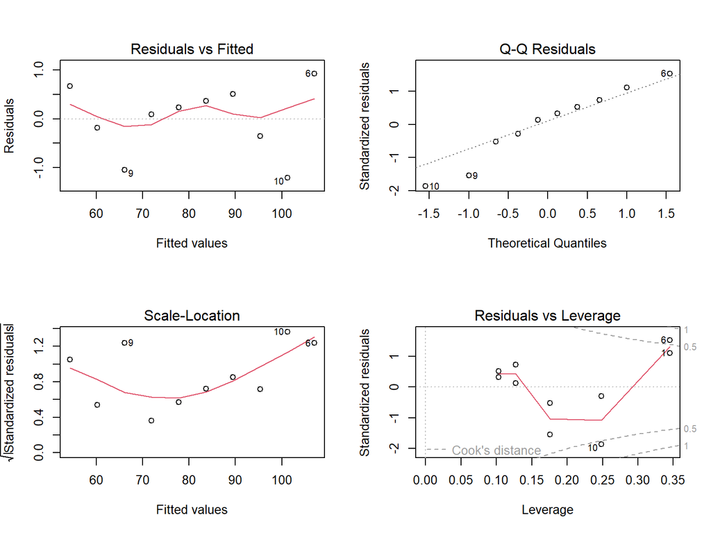

```r
par(mfrow = c(2, 2))
plot(model)
```

```r
par(mfrow = c(1, 1))
```

**Interpretation of diagnostic plots:**

- *Residuals vs Fitted*: look for a random horizontal band around 0 — a curved pattern would flag non-linearity; a funnel shape would flag heteroscedasticity.
- *Normal Q-Q*: points should hug the diagonal line; systematic curvature at the tails flags non-normal errors.
- *Scale-Location*: similar to residuals vs fitted, checks constant variance.
- *Residuals vs Leverage*: flags influential points (watch for points outside Cook’s distance contours).

With only $n=10$ points these diagnostics are illustrative rather than conclusive — worth telling students that formal tests (Shapiro-Wilk, Breusch-Pagan, covered in Topic 4) become more useful with larger samples, and normally you’d want a bigger dataset before trusting the diagnostics fully.